# 第四讲 概率统计与资产收益率

# 0. 准备工作

# 1. 概率统计基本概念

## 1.1 概率空间和概率

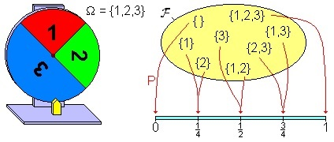

若函数 $P: \mathscr{F} \rightarrow[0,1]$ 满足：

- 非负性 $P(A) \geq 0$
- 规一性 $P(\Omega)=1$
- 可列可加性，即如果 $A_{i} \in \mathscr{F}$ 且 $A_{i} A_{j}=\emptyset,(i \neq j)$

则称 $P$ 为可测空间 $(\Omega, \mathscr{F})$ 上的一个概率测度（probability measure)，简称概率。

## 1.2 随机变量

- **定义**：

  如果定义在样本空间上的实值函数 $X: \Omega \rightarrow \mathbb{R}$ 对任意 $x \in \mathbb{R}$ 有：
  $$\{\omega: X(\omega) \leq x\} \in \mathscr{F}$$
  则称 $X$ 为 $(\Omega, \mathscr{F}, P)$ 上的随机变量。
- **分类**：
  - 离散型随机变量：如二项分布（伯努利分布， `binom`) 、泊松分布 pois 等 。
  - 连续型随机变量：如均匀分布unif、正态分布（高斯分布，norm）、指数分布exp，以及t、F、$^{2}$ ( t. F. chisq）分布等。 ・ 累积分布函数 $F: \mathbb{R} \rightarrow[0,1]:$ $X$ 是概率空间 $(\Omega, \mathscr{F}, P)$ 上的随机变量，若对于 $\forall x \in \mathbb{R}$ 存在
    $$F(x)=P(X \leq x)$$
    则称 $F: \mathbb{R} \rightarrow[0,1]$ 为累积分布函数 （cumulative distribution function, cdf) 。
- **概率密度函数** $f: \mathbb{R} \rightarrow[0, \infty):$ 对连续随机变量 $X,$ 如果除有限个点外存在：
  $$f(x)=\frac{d F}{d x}, \quad \int_{-\infty}^{x} f(u) d u=P(X \leq x)=F(x)$$
  称 $f: \mathbb{R} \rightarrow[0, \infty)$ 为概率密度函数（probability density function, pdf）。
- **频率函数或分布律**：对于离散随机变量 $X \in\left\{x_{i}\right\}_{i=1}^{N},$ 称 $p\left(x_{i}\right)=P\left(X=x_{i}\right)$ 为频率函数（frequency function）或分布律。

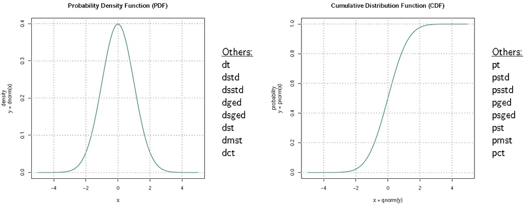

## 1.3 样本统计量

$\left\{x_{t}\right\}_{t=1}^{T}$ 是随机变量 $X$ 的 $T$ 个独立抽取的样本，常用的样本统计量（sample statistics) 定义如下:
1. 样本均值（sample mean）：
$$\hat{\mu}_{x}=\frac{1}{T} \sum_{t=1}^{T} x_{t}$$
2. 样本方差/标准差（sample variance / standard deviation）：
$$\hat{\sigma}_{x}^{2}=\frac{1}{T-1} \sum_{t=1}^{T}\left(x_{t}-\hat{\mu}_{x}\right)^{2}$$
3. 样本偏度（sample skewness）：
$$\hat{S}_{x}=\frac{1}{(T-1) \hat{\sigma}_{x}^{3}} \sum_{t=1}^{T}\left(x_{t}-\hat{\mu}_{x}\right)^{3}$$
4. 样本峰度（sample kurtosis）：
$$\hat{K}_{x}=\frac{1}{(T-1) \hat{\sigma}_{x}^{4}} \sum_{t=1}^{T}\left(x_{t}-\hat{\mu}_{x}\right)^{4}$$
此外，假定 $\left\{y_{i}\right\}_{i=1}^{N}$ 是随机变量 $Y$ 的 $N$ 个独立抽取的样本，定义 :

1. 协方差（covariance）:
   $$C o v_{x y}=\frac{1}{N-1} \sum_{i=1}^{N}\left(x_{i}-\hat{\mu}_{x}\right)\left(y_{i}-\hat{\mu}_{y}\right)$$
2. 相关系数（correlation coefficient）：
   $$\rho_{x y}=\frac{C o v_{x y}}{\hat{\sigma}_{x} \hat{\sigma}_{y}}$$

**注意**:

- 如果 $X$ 是一个正态分布的随机变量，则 $\hat{S}_{x}$ 和 $\hat{K}_{x}-3$ 的分布渐近为均值为零、方差分别为 $6 / T$ 和 $24 / T$ 的正态分布。
- 定义 $\hat{K}_{x}-3$ 为超额峰度（excess kurtosis）。与正态分布相比， $\hat{K}_{x}>3$ 的分布呈现出 **尖峰 (leptokurtic)** **厚尾（fat-tailed）** 的特征，也就是存在更多的极端值。
- 统计量是样本的函数，样本不同统计量也不同，因此 **统计量本身也是一个随机变量** ;
- 统计量的分布称为 抽样分布（sample distribution），它与随机变量 X 所服从的 **总体分布（population distribution）** 是两个不同的概念。比如根据中心极限定理，不论 X 服从哪种分布，在一定条件下，样本均值 $\bar{x}$ 都将渐近服从正态分布 $N\left(\mu, \sigma^{2} / N\right)$ 。

## 1.4 统计推断

- 定义：根据样本判断关于总体分布 $X \sim F(x)$ 的假设是否正确。
- 分类:
  - 参数检验：给定总体分布的类型，检验对分布参数的假定是否正确
    $$H_{0}: \theta \in \Theta$$
  - 分布检验：检验对总体分布类型的假定是否正确
    $$H_{0}: X \sim F(x)$$

# 2. R语言实现

## 2.1 概率函数

四种前缀（以正态分布 $x \sim N\left(\mu, \sigma^{2}\right)$ 为例）：

- d: 概率密度函数或频率函数 `dnorm(x,mu, sigma)`
- p: 累积分布函数 `pnorm(x,mu,sigma)`
- q: 给定概率 $\alpha,$ 求累积分布的右侧分位点 `qnorm(1-alpha/2,mu,sigma)`
- r: 生成随机数 `rnorm(N,mu,sigma)`

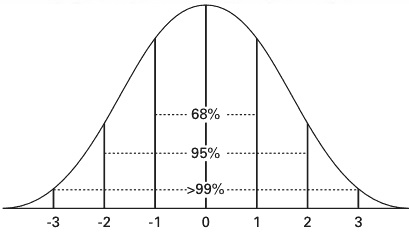

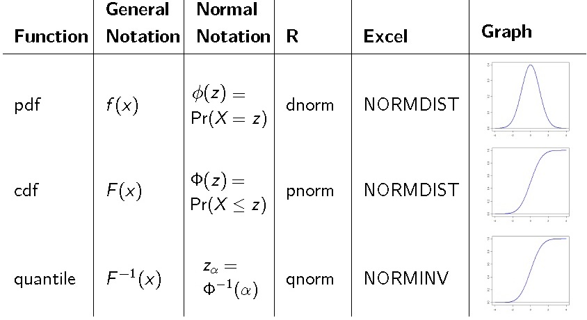

```r
x <- seq(from = -5, to = 5, by = 0.01)            # 横轴向量
y <- dnorm(x)                                     # 正态分布的概率密度函数
plot(x=x,y=y, type="l",col="seagreen",lwd=2,
  xlab="x",ylab="density\ny = dnorm(x)")
grid(col="darkgrey",lwd=2)
title(main="概率分布(PDF)")
y <- pnorm(x)                                     # 正态分布的累积分布函数
plot(x=x,y=y,type="l",col="seagreen",lwd=2, xlab="x = qnorm(y)",
   ylab="probability\ny = pnorm(x)")  ; grid(col="darkgrey",lwd=2)
title(main="累积分布(CDF)")
set.seed(1)
x <- rnorm(100, sd=3)                             # 模拟生成单变量
y <- rnorm(100, mean=1) + x
mn = apply(cbind(x,y), 2, mean)                   # 计算x和y的均值
covmat= cov(cbind(x,y))                           # 计算x和y的协方差
simdata=rmnorm(300,mean=mn,varcov=covmat)         # mnormt包中函数，模拟生成双变量
ggplot(as.data.frame(simdata), aes(x=x, y=y)) +
  geom_point() +geom_smooth(method="lm") + theme_bw()
```

[output not shown]

## 2.2 统计描述

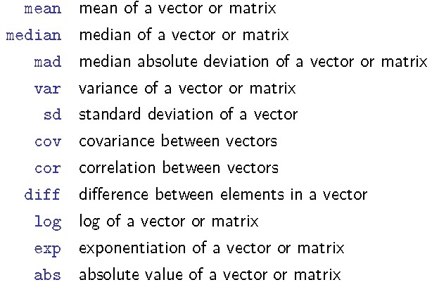

```r
library(MASS)
data(Insurance)                                  # 调用保险数据
str(Insurance)                                   # 查看数据结构
attach(Insurance)                                # 绑定数据
```

[output not shown]

- 单变量统计描述

```r
# 1）连续变量
mean(Holders)                                    # 基本统计量，有缺失值时用 mean(Holders, na.rm = TRUE)
median(Holders)
sd(Holders)
var(Holders)
quantile(Holders)                                # 四分位值
quantile(Holders,seq(0,1,0.1))                   # 十分位值
library(Hmisc)
describe(data.frame(District, Group, Age))       # 简单数据描述
describe(data.frame(Holders, Claims))
library(fBasics)
basicStats(data.frame(Holders, Claims))          # 更多统计量

# 2）离散变量
table(Age)                                       # 离散变量频率表
```

[output not shown]

- 双变量统计描述

```r
# 1）两个连续变量
cor(data.frame(Holders, Claims),use="pairwise",method="pearson") # 相关系数
cov(data.frame(Holders, Claims),use="pairwise",method="pearson") # 协方差矩阵
# 2）一个连续变量和一个离散变量
by(data.frame(Holders,Claims),Age,summary)       # 按离散变量分组，对连续变量做统计描述
# 3）两个离散变量
table(District,Age)                              # 两个离散变量频率表
detach(Insurance)                                # 解除绑定
```

[output not shown]

## 2.3 统计推断

- **参数检验**
  - 正态分布 $X \sim N\left(\mu, \sigma^{2}\right)$
    - 均值检验 $\left(\sigma^{2}\right.$ 未知) t.text()：单变量 $H_{0}: \mu=\mu_{0},$ 双变量 $H_{0}: \mu_{1}=\mu_{2}$
    - 方差检验（ $\mu$ 未知) : var.text()：单变量 $H_{0}: \sigma^{2}=\sigma_{0}^{2},$ 双变量 $H_{0}: \sigma_{1}^{2}=\sigma_{2}^{2}$
  - 总体分布未知，单变量或双变量均值检验： wi l cox. test()
- **分布检验**：单变量 $H_{0}: X \sim F(x),$ 双变量 $H_{0}: F_{1}(x)=F_{2}(x)$
  - Jarque-Bera $J B$ 检验 normal Test()
  - Pearson $\chi^{2}$ 检验 chisq.test()
  - Kolmogorov-Smirnov检验 ks.test()

# 3. 应用

## 3.1 收益率基本概念

### 3.1.1 资产收益率

1. $k$ 期简单净收益率(simple return)
   $$R_{t}[k]=\frac{P_{t}}{P_{t-k}}-1$$
2. $k$ 期简单毛收益率(gross return)或复合收益率(compound return)
   $$1+R_{t}[k]=\frac{P_{t}}{P_{t-k}}=\frac{P_{t}}{P_{t-1}} \frac{P_{t-1}}{P_{t-2}} \ldots \frac{P_{t-k+1}}{P_{t-k}}=\prod_{j=0}^{k-1}\left(1+R_{t-j}\right)$$
3. 连续复合收益率(continuous compounding return) 或对数收益率(log-return)
   $$\begin{array}{c}
   r_{t}=\ln \left(1+R_{t}\right)=\ln \frac{P_{t}}{P_{t-k}}=p_{t}-p_{t-1} \\
   r_{t}[k]=\sum_{j=0}^{k-1} r_{t-j}
   \end{array}$$

**注意**：

当净收益率很小时，近似等于对数收益率。

```r
# 比较净收益率和对数收益率
R <- seq(-0.2,0.2,len=100)
data=data.frame(R, r=log(1+R))
ggplot(data,aes(R,r)) +
  geom_line() +
  geom_abline(slope=1, intercept=0, color="red") +
  labs(title ="对数收益率（r）和简单净收益率（R）", x = "R", y = "r= log(1+R)") +
  theme_bw()
```

[output not shown]

- 由于简单净收益率的下限为-1，因此一般不能假定 $R_{t}$ 服从正态分布，而对数收益率的取值为整个实数 域，因此一般假定 $r_{t} \sim N\left(\mu, \sigma^{2}\right),$ 相应的 $R_{t}$ 服从对数正态分布，均值和方差分别为:
  $$\begin{array}{c}
  E\left(R_{t}\right)=\exp \left(\mu+\sigma^{2} / 2\right)-1 \\
  \operatorname{Var}\left(R_{t}\right)=\exp \left(2 \mu+\sigma^{2}\right)\left[\exp \left(\sigma^{2}\right)-1\right]
  \end{array}$$

4.年化复合收益率
$$\bar{R}_{t}[k]=\left[\prod_{j=0}^{k-1}\left(1+R_{t-j}\right)\right]^{\frac{1}{k}}-1 \approx \frac{1}{k} \sum_{j=0}^{k-1} R_{t-j}$$
$$\bar{r}_{t}[k]=\frac{1}{k} \sum_{j=0}^{k-1} r_{t-j} \approx \bar{R}_{t}[k]$$
其他相关定义：

- 资产组合收益率（wi为资产权重）：
  $$R_{t}^{p}=\sum_{i=1}^{N} w_{i} R_{i t}, \quad r_{t}^{p} \approx \sum_{i=1}^{N} w_{i} r_{i t}$$
- 含红利支付 $D_{t}:$
  $$R_{t}=\frac{P_{t}+D_{t}}{P_{t-1}}-1, \quad r_{t}=\ln \left(P_{t}+D_{t}\right)-\ln P_{t-1}$$
- 超额收益率（参照资产标记为0）：
  $$Z_{t}=R_{t}-R_{t}^{0}, \quad z_{t}=r_{t}-r_{t}^{0}$$

```r
## 价格为不同数据类型，计算收益率
  # 1) 向量
P <- c(265.50, 264.27, 266.49, 253.81, 269.20, 277.69, 301.22, 280.98, 312.64,
  364.03, 393.62, 398.79)
P[-length(P)]                        # P(1), P(2) ... P(T-1)
P[-1]                                # P(2), P(3) ... P(T)
R <- P[-1] / P[-length(P)] - 1       # R(t) = P(t+1)/P(t) -1
R <- diff(P) / P[-length(P)]         #        [P(t+1) - P(t)]/P(t)
r <- diff(log(P))                    # r(t) = log(P(t+t)) - log(P(t))
  # 2) zoo 对象
library(zoo)
z <- zooreg(P, as.yearmon("2013-01"), freq = 12)
R.z <- diff(z) / lag(z,-1)  # 指定 lag=-1
r.z <- diff(log(z))
  # 3) xts 对象
library(xts)
x <- as.xts(z)
R.x <- diff(x) / lag(x)     # 默认 lag=1
r.x <- diff(log(x))
  # 4) timeSeries 对象
library(timeSeries)
r.ts= returns(P)
  # 比较上述计算结果，注意xts和timeSeries的第一期为NA
  comp= data.frame(r, r.z, r.x[-1], r.ts[-1])  # 四种结果列为数据框
  round(comp,3)                                # 保留3位小数
```

[output not shown]

### 3.1.2 债券收益率

记债券价格为 $B$ 、利息为$C$、面值（par value）为$F$。

1. 票面利率
   $$\text { coupon rate }=\frac{C}{F}$$
2. 当期收益率
   $$\text { spot return }=\frac{C}{B}$$
3. 到期收益率 $r$ (yield to maturity, YTM)
   $$B=\frac{C_{1}}{1+r}+\frac{C_{2}}{(1+r)^{2}}+\ldots+\frac{C_{T}+F}{(1+r)^{T}}$$

3.1.3 汇率升(贴)水率
$$r_{t}=\frac{E_{t}}{E_{t-1}}-1$$

```r
# 计算股票、债券、汇率的收益率
library(quantmod)
loadSymbols("AAPL")                            # 苹果股票
```

[output not shown]

```
[1] "AAPL"
```

```r
loadSymbols("^TNX")                            # 10年期美国国债收益率
```

```
^TNX contains missing values. Some functions will not work if objects contain missing values in the middle of the series. Consider using na.omit(), na.approx(), na.fill(), etc to remove or replace them.
```

```
[1] "^TNX"
```

```r
loadSymbols("DEXUSEU",src="FRED")              # 汇率，1欧元等于E美元
```

```
[1] "DEXUSEU"
```

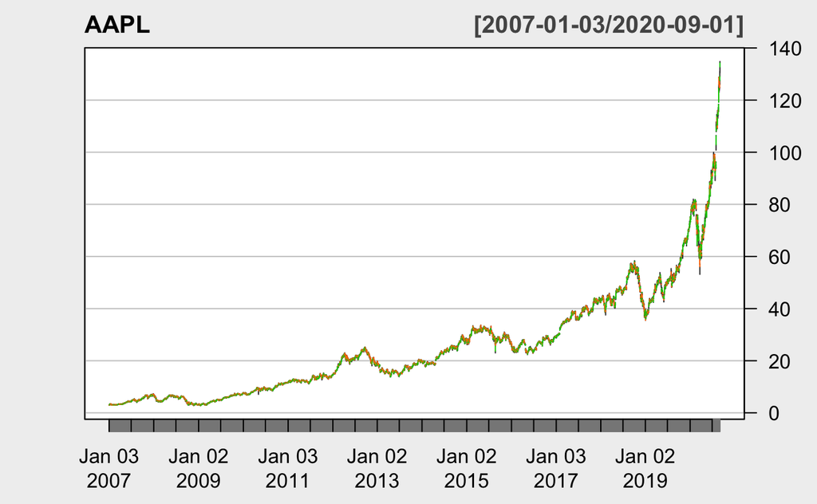

```r
# 如果无法直接下载，可通过 load("price.Rdata") 调用数据
chartSeries(AAPL,theme="white",TA=NULL)        # 股价，TA=NULL则不包括成交量
```

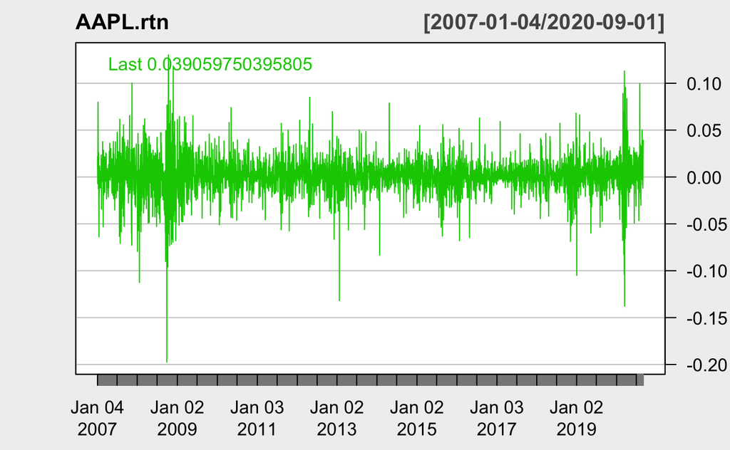

```r
AAPL.rtn=diff(log(AAPL$AAPL.Adjusted))         # 经调整的股价对数收益率
chartSeries(AAPL.rtn,theme="white")
```

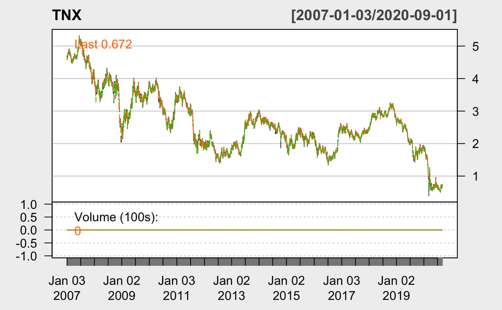

```r
chartSeries(TNX,theme="white")
```

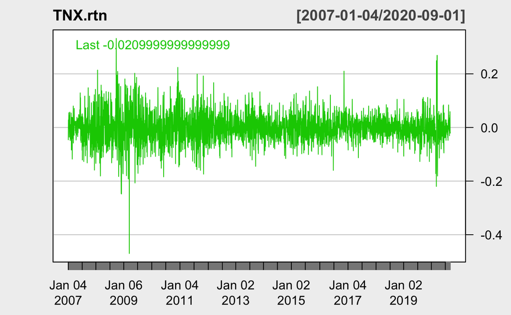

```r
TNX.rtn=diff(TNX$TNX.Adjusted)                 # 债券收益率(%)的变化率
chartSeries(TNX.rtn,theme="white")
```

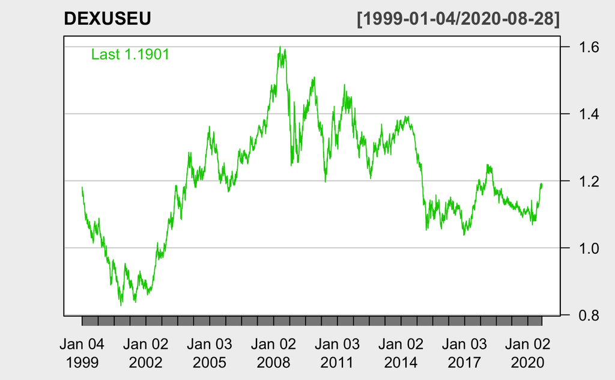

```r
chartSeries(DEXUSEU,theme="white")
```

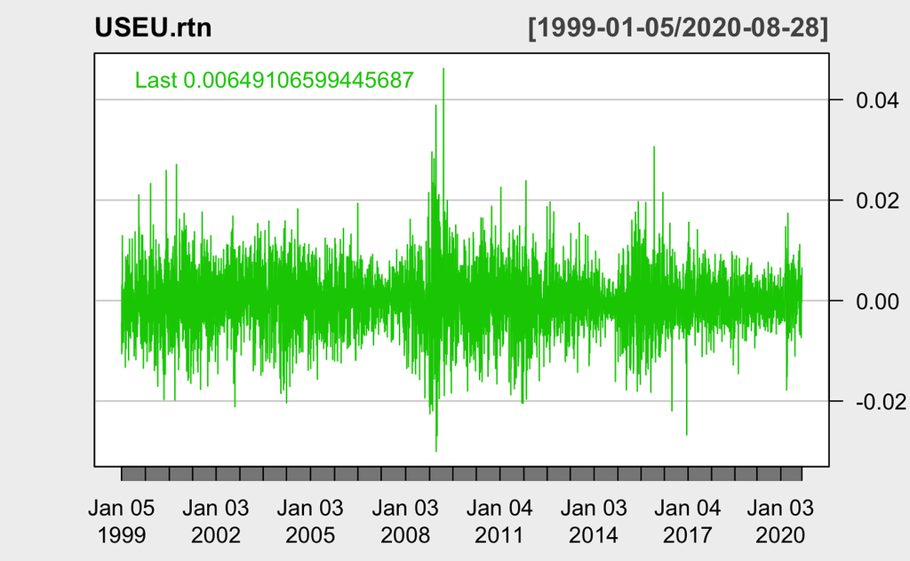

```r
USEU.rtn=diff(log(DEXUSEU$DEXUSEU))            # 汇率变化率
chartSeries(USEU.rtn,theme="white")
```

## 3.2 资产收益率的特征事实

根据 Fan and Yao(2015) 资产收益率具有以下典型特征：

- 平稳性(stationarity)： $r_{t}$ 有稳定的均值和有限的方差
- 厚尾性(heavy tails)：峰度$\hat{K}>3,$与正态分布相比呈现出尖峰厚尾的特征，说明出现爆涨和爆跌的概率大于正态分布。
- 非对称性(asymmetry)： $r_{t}$ 的分布呈现负偏（negatively skewed）特征，说明市场下跌比上涨的程度大。
- 波动集聚性(volatility clustering)：指市场会连续大幅上涨(或下跌)。
- 加总高斯性(aggregational Gaussianity)：当时间跨度上升时，相应的收益率会趋向正态分布，如年收益率与月收益率和日收益率相比，更接近于正态分布。
- 长期记忆性(Iong-memory properties)：即各期收益率之间存在相关性。
- 杠杆效应(leverage effect)：当收益率为负（即股价下跌）时，企业杜杆率上升、风险上升，股票波动性 也随之上升，这种收益率和波动性变化率之间的负相关关系被称为杜杆效应。

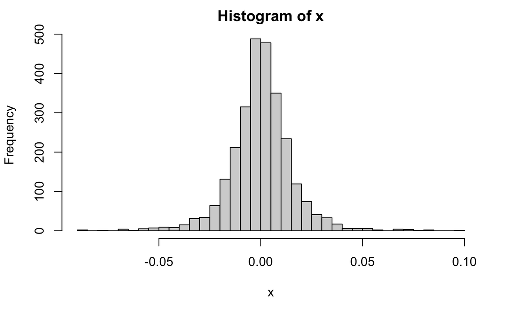

```r
# 以苹果的对数收益率为例
x=as.data.frame(AAPL.rtn)[,1]
# 或者用 Tsay(2013)中3M公司数据
url="https://faculty.chicagobooth.edu/ruey.tsay/teaching/introTS/ch1data.zip"
download.file(url, "ch1data.zip")                           # 下载存为同名文件
x=read.table(unz("ch1data.zip","d-mmm-0111.txt"),header=T)  # 读入数据
x=x[,2]                                                     # 去掉日期
# 1) 作图
hist(x,nclass=30)                                           # 直方图
```

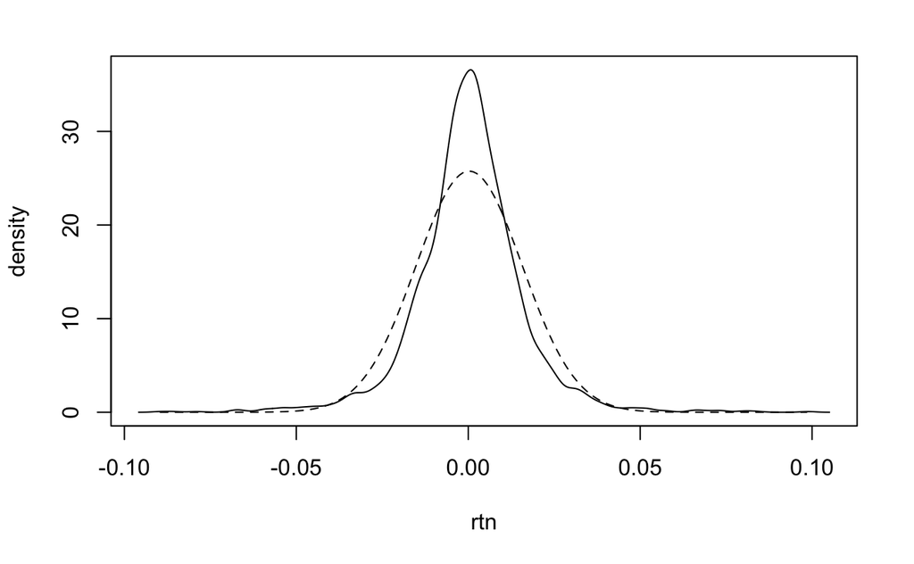

```r
d1=density(x,na.rm=T)                                       # 密度
plot(d1$x,d1$y,xlab='rtn',ylab='density',type='l')          # 密度线
rangex=range(x,na.rm=T)                                     # 取值范围
seqx=seq(rangex[1],rangex[2],.001)                          # x轴间隔0.001
y1=dnorm(seqx,mean(x,na.rm=T),stdev(x,na.rm=T))             # 正态分布
lines(seqx,y1,lty=2)                                        # 添加正态分布线
```

```r
# 2) 检验
library(fBasics)
basicStats(x)
```

|  | x |
| --- | --- |
| nobs | 2704.000000 |
| NAs | 0.000000 |
| Minimum | -0.089569 |
| Maximum | 0.098784 |
| 1. Quartile | -0.007161 |
| 3. Quartile | 0.007987 |
| Mean | 0.000278 |
| Median | 0.000349 |
| Sum | 0.751082 |
| SE Mean | 0.000298 |

[output cut: 6 more lines]

```r
mean(x,na.rm=TRUE); var(x,na.rm=TRUE); stdev(x,na.rm=TRUE);
```

```
[1] 0.000277767
[1] 0.0002398835
[1] 0.01548817
```

```r
t.test(x)                                                   # 均值检验 H0: x=0
```

```
    One Sample t-test

data:  x
t = 0.93258, df = 2703, p-value = 0.3511
alternative hypothesis: true mean is not equal to 0
95 percent confidence interval:
 -0.0003062688  0.0008618028
sample estimates:
  mean of x
0.000277767
```

```r
normalTest(x,method='jb',na.rm=T)                           # 正态分布检验，JB-test
```

```
Title:
 Jarque - Bera Normalality Test

Test Results:
  STATISTIC:
    X-squared: 2422.4384
  P VALUE:
    Asymptotic p Value: < 2.2e-16

Description:
 Wed Sep  2 17:13:30 2020 by user:
```

```r
s3=skewness(x,na.rm =T)
T=length(x)
t3=s3/sqrt(6/T)
pp=2*(1-pnorm(t3))                                          # 偏度检验(Skewness test)
s4=kurtosis(x,na.rm =T)
t4=s4/sqrt(24/T)
pp=2*(1-pnorm(t4))                                          # 峰度检验(Kurtosis test)
```